# Data Science Summer Sessions

World Happiness Report

Adriana Picoral

Summer 2022

# 1 The data

In this tutorial we will be working with data from the [World Happiness Report](https://worldhappiness.report/), a project that collects global survey data on how people evaluate their own lives in more than 150 countries worldwide. I downloaded [the data from kaggle](https://www.kaggle.com/datasets/mathurinache/world-happiness-report), and cleaned it to have common variables match. First download [the clean data](https://raw.githubusercontent.com/picoral/dsa-summer-2022/master/data/world_happiness.csv) and place it in a data folder in your project.

```r
library(tidyverse)
world_happiness <- read_csv("data/world_happiness.csv")
```

Not all variables are present for all years in the data, since these are yearly reports and the methods for data collection slightly change from year to year. You can get more information about the specifics of each year data collection from the [World Happiness Report website](https://worldhappiness.report/).

# 2 Happiness and Healthy Life Expectancy

```r
world_happiness_2020_2021 <- world_happiness %>%
  filter(year == 2020 | year == 2021)
```

Our question relates to `the relationship between happiness score and healthy life expectancy in years`. Let’s plot a scatterplot with these two numeric variables mapped to the axes. We will also add a regression line to the plot using `geom_smooth()`.

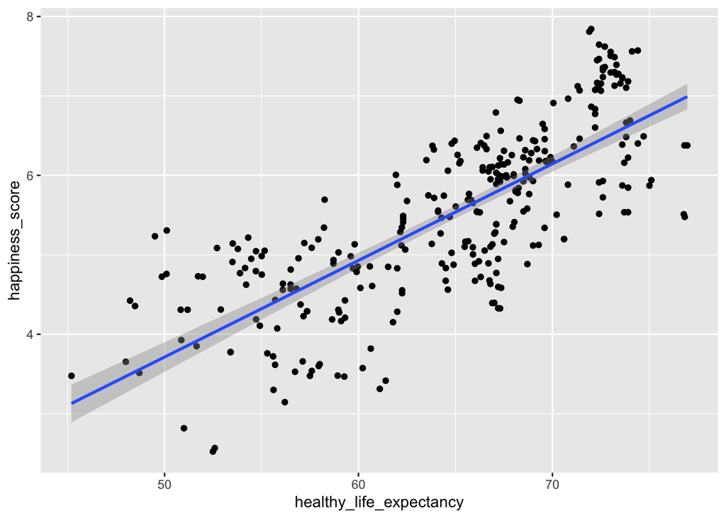

```r
world_happiness_2020_2021 %>%
  ggplot(aes(x = healthy_life_expectancy,
             y = happiness_score)) +
  geom_point() +
  geom_smooth(method = "lm")
```

Note that for our regression line in the plot above we used `method = "lm"` for a linear regression model. Let’s run `lm()` with `happiness_score` as the dependent variable and `healthy_life_expectancy` as a predictor.

```r
model_life_expc <- lm(happiness_score ~ healthy_life_expectancy,
                      data = world_happiness_2020_2021)
```

We now run `summary()` on the object we just created to get the coefficients and other information on the model.

```r
summary(model_life_expc)
```

```
##
## Call:
## lm(formula = happiness_score ~ healthy_life_expectancy, data = world_happiness_2020_2021)
##
## Residuals:
##      Min       1Q   Median       3Q      Max
## -1.75036 -0.52377  0.09883  0.56299  1.58125
##
## Coefficients:
##                         Estimate Std. Error t value Pr(>|t|)
## (Intercept)             -2.37033    0.37944  -6.247 1.43e-09 ***
## healthy_life_expectancy  0.12165    0.00583  20.866  < 2e-16 ***
## ---
## Signif. codes:  0 '***' 0.001 '**' 0.01 '*' 0.05 '.' 0.1 ' ' 1
##
## Residual standard error: 0.6987 on 300 degrees of freedom
## Multiple R-squared:  0.5921, Adjusted R-squared:  0.5907
## F-statistic: 435.4 on 1 and 300 DF,  p-value: < 2.2e-16
```

We can save this summary to an object, and then retrieve specifics measures using `$`.

```r
model_summary <- summary(model_life_expc)

model_summary$adj.r.squared
```

```
## [1] 0.5906958
```

```r
model_summary$coefficients
```

```
##                           Estimate  Std. Error   t value     Pr(>|t|)
## (Intercept)             -2.3703328 0.379445435 -6.246835 1.431746e-09
## healthy_life_expectancy  0.1216551 0.005830274 20.866107 2.322673e-60
```

# 3 Change in happiness scores over the years

Let’s turn our attention to the entire data set. There are a total of 165 countries in the data, which is too much for visualizing all at once. Let’s filter our data to look at some selected countries using `%in%`.

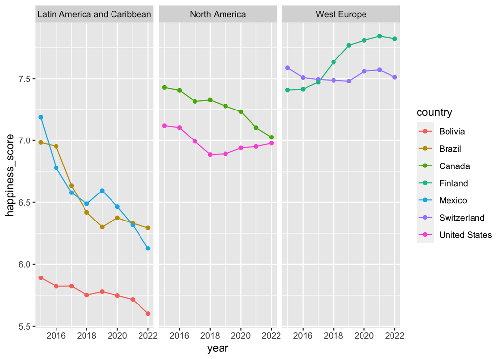

```r
world_happiness %>%
  filter(country %in% c("United States", "Brazil", "Canada", "Mexico", "Bolivia",
                        "Switzerland", "Finland")) %>%
  ggplot(aes(x = year,
             y = happiness_score,
             color = country)) +
  geom_point() +
  geom_line() +
  facet_wrap(~region)
```

It looks like there’s an interaction between region and year.

# 4 Effect of categorical variable

We can run our linear regression with categorical predictors, like region.

```r
model_region <- lm(happiness_score ~ region,
                   data = world_happiness)

summary(model_region)
```

```
##
## Call:
## lm(formula = happiness_score ~ region, data = world_happiness)
##
## Residuals:
##      Min       1Q   Median       3Q      Max
## -2.41495 -0.42399  0.03193  0.47273  2.07242
##
## Coefficients:
##                                    Estimate Std. Error t value Pr(>|t|)
## (Intercept)                          7.2681     0.1752  41.478  < 2e-16 ***
## regionCentral and East Europe       -1.7126     0.1812  -9.453  < 2e-16 ***
## regionEast Asia                     -1.5608     0.2023  -7.714 2.53e-14 ***
## regionLatin America and Caribbean   -1.2712     0.1832  -6.937 6.47e-12 ***
## regionMiddle East and North Africa  -1.9766     0.1845 -10.712  < 2e-16 ***
## regionNorth America                 -0.1447     0.2478  -0.584   0.5593
## regionSouth Asia                    -2.7530     0.1991 -13.828  < 2e-16 ***
## regionSoutheast Asia                -1.9054     0.1940  -9.823  < 2e-16 ***
## regionSub-Saharan Africa            -2.9844     0.1798 -16.603  < 2e-16 ***
## regionWest Europe                   -0.4666     0.1834  -2.544   0.0111 *
## ---
## Signif. codes:  0 '***' 0.001 '**' 0.01 '*' 0.05 '.' 0.1 ' ' 1
##
## Residual standard error: 0.7009 on 1220 degrees of freedom
##   (1 observation deleted due to missingness)
## Multiple R-squared:  0.608,  Adjusted R-squared:  0.6051
## F-statistic: 210.2 on 9 and 1220 DF,  p-value: < 2.2e-16
```

The interpretation of results with a categorical variable with lots of levels using just `summary()` is really difficult. To get the effect of each level, I use the function `effect()` from the `effects` package.

```r
library(effects)
region_effect <- effect("region", model_region) %>%
  data.frame()


region_effect %>%
  kable()
```

| region | fit | se | lower | upper |
| --- | --- | --- | --- | --- |
| Australia and New Zealand | 7.268150 | 0.1752282 | 6.924368 | 7.611932 |
| Central and East Europe | 5.555517 | 0.0460172 | 5.465236 | 5.645799 |
| East Asia | 5.707398 | 0.1011680 | 5.508915 | 5.905881 |
| Latin America and Caribbean | 5.996950 | 0.0536001 | 5.891792 | 6.102109 |
| Middle East and North Africa | 5.291576 | 0.0578103 | 5.178158 | 5.404995 |
| North America | 7.123419 | 0.1752282 | 6.779637 | 7.467201 |
| South Asia | 4.515184 | 0.0945111 | 4.329761 | 4.700606 |
| Southeast Asia | 5.362723 | 0.0831830 | 5.199525 | 5.525920 |
| Sub-Saharan Africa | 4.283713 | 0.0400685 | 4.205103 | 4.362324 |
| West Europe | 6.801593 | 0.0540766 | 6.695499 | 6.907686 |

We can plot these results, so they are easier to read. Remember that region is an unordered categorical variable, so we should `reorder` region by the fit (in this case the fit is the average happiness score).

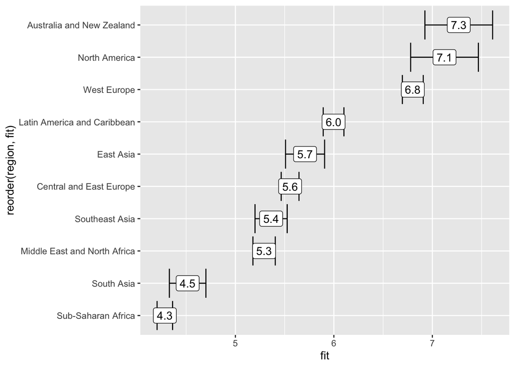

```r
region_effect %>%
  ggplot(aes(y = reorder(region, fit),
             x = fit,
             xmin = lower,
             xmax = upper)) +
  geom_errorbar() +
  geom_label(aes(label = format(fit, digits = 2)))
```

# 5 Multifactorial analysis

We can add predictors to our model with the `+` symbol.

```r
model_multivariate <- lm(happiness_score ~ region + year,
                           data = world_happiness)

summary(model_multivariate)
```

```
##
## Call:
## lm(formula = happiness_score ~ region + year, data = world_happiness)
##
## Residuals:
##      Min       1Q   Median       3Q      Max
## -2.44861 -0.41780  0.05043  0.45526  2.07189
##
## Coefficients:
##                                      Estimate Std. Error t value Pr(>|t|)
## (Intercept)                        -43.862613  17.631787  -2.488   0.0130 *
## regionCentral and East Europe       -1.712633   0.180622  -9.482  < 2e-16 ***
## regionEast Asia                     -1.560752   0.201724  -7.737 2.12e-14 ***
## regionLatin America and Caribbean   -1.267867   0.182692  -6.940 6.36e-12 ***
## regionMiddle East and North Africa  -1.973386   0.183964 -10.727  < 2e-16 ***
## regionNorth America                 -0.144731   0.247061  -0.586   0.5581
## regionSouth Asia                    -2.751354   0.198490 -13.861  < 2e-16 ***
## regionSoutheast Asia                -1.905963   0.193384  -9.856  < 2e-16 ***
## regionSub-Saharan Africa            -2.982615   0.179209 -16.643  < 2e-16 ***
## regionWest Europe                   -0.466557   0.182828  -2.552   0.0108 *
## year                                 0.025331   0.008735   2.900   0.0038 **
## ---
## Signif. codes:  0 '***' 0.001 '**' 0.01 '*' 0.05 '.' 0.1 ' ' 1
##
## Residual standard error: 0.6988 on 1219 degrees of freedom
##   (1 observation deleted due to missingness)
## Multiple R-squared:  0.6107, Adjusted R-squared:  0.6075
## F-statistic: 191.2 on 10 and 1219 DF,  p-value: < 2.2e-16
```

And here’s a question for reflection: year is a numeric variable in the model above, so the intercept is for year zero – does that make sense? How would you fix that?

# 6 Video demonstration

[video not shown]